# aqim pathway approach rates

Dalon White

2025-07-27

- prepped data already has the pathway, entry type, etc., and risk as no/low/med/high
- need to use country of origin and product origin to determine if the inspection has any asf risk
- then model the kg of product with asf risk by pathway, entry type, location, country of origin, product pathway, product subpathway

```r
# Function to load the shared parameters if available
load_shared_params <- function() {
  params_file <- here::here("output", "intermediate files", "asf_risk_params.rds")

  if (file.exists(params_file)) {
    message("Loading shared parameters from 00_asf_risk_parameters.Rmd")
    return(readRDS(params_file))
  } else {
    message("Shared parameter file not found. Using script-specific parameters.")
    return(NULL)
  }
}

# Try to load shared params
shared_params <- load_shared_params()
```

```
## Loading shared parameters from 00_asf_risk_parameters.Rmd
```

```r
# Use shared params if available, otherwise use script-specific params
if (!exists("params")) {
  if (!is.null(shared_params)) {
    params <- shared_params
  } else {
    # Default params specific to this script
    params <- list(
      risk_quantification = "0_1", # 0_1 or "range"
      affected_countries = "current", # "current" or "mex_can" or "other"
      years = 2024:2024, #The years to include which countries have ASF
      other_affected_countries = c("Country1", "Country2"),
      glm_results_filename = "glmm_results_aqim fraction at risk by pathway and location",
      bootstrap_results_filename = "bootstrap_results_aqim fraction at risk by pathway and location",
      group_size_filename = "aqim_mean_pathway_group_size"
    )
  }
}
```

# Call AQIM data

```r
aqim_dat <- read.csv("C:/Users/Dalon.White/OneDrive - USDA/Desktop/Projects/asf-risk-framework-large-files/aqim pathway data prep.csv")
```

# Save group size for later calculations

```r
View(aqim_dat |> count(group_size, PATHWAY))
# If group_size is NA or 0, replace with 1
# for each pathway, find the average group size
group_size_summary <- aqim_dat %>%
  mutate(group_size = case_when(
    group_size == 0 ~ 1,
    is.na(group_size) ~ 1,
    .default = group_size
  )) %>%
  group_by(PATHWAY) %>%
  summarize(
    avg_group_size = mean(group_size, na.rm = TRUE),
    median_group_size = median(group_size, na.rm = TRUE),
    min_group_size = min(group_size, na.rm = TRUE),
    max_group_size = max(group_size, na.rm = TRUE),
    count = n()
  )
```

# Set affected countries for analysis

Within params, can choose whether to use the current affected countries or just Mexico and Canada. The current ones, are then filtered by the years specified in params$years. If only interested in the last year, then set params$years to the last year of interest. It is important to remember that we are not predicting where surveillance needs to be, such as for the CEAH group, but identifying the risk of ASF in products that are coming into the US, so whether an item corresponds to a year and country is not important. Instead, we are focused on estimating how much comes from each country and whether that country has ASF risk.

```r
setwd(here::here("input","data","asf affected countries by year"))
if(params$affected_countries == "current") {
  affected_countries <- read.csv("asf affected countries.csv") |>
    mutate(Year = as.numeric(Year)) |>
    filter(Year %in% params$years) |>
    filter(Disease == "ASF") |>
    distinct(ISO3_CODE) |>
    pull(ISO3_CODE)
} else if (params$affected_countries == "mex_can") {
  affected_countries <- c("MEX", "CAN")
} else if (params$affected_countries == "other") {
  affected_countries <- params$other_affected_countries
} else {
  stop("Invalid value for params$affected_countries")
}
```

# Assign risk by country of origin and product origin

```r
# Filter for affected countries
aqim_dat <- aqim_dat %>% mutate(IS_ASF_RISK = case_when(
  edge_origin %in% affected_countries | product_origin %in% affected_countries ~ IS_ASF_RISK,
  .default = "NO"
         )
)
#once it is filtered by country, this is the at risk products by weight. For example:
aqim_dat |> filter(PATHWAY== "Pedestrian SB") |> count(TOTAL_KG > 0, IS_ASF_RISK)
```

```
##   TOTAL_KG > 0 IS_ASF_RISK      n
## 1         TRUE        HIGH    258
## 2         TRUE         LOW      9
## 3         TRUE      MEDIUM    297
## 4         TRUE          NO   6713
## 5           NA          NO 287286
```

## handle risk quantification based on 0-1 or a scale

```r
if(params$risk_quantification == "0_1") {
  # Convert risk to binary (0 or 1)
  aqim_dat <- aqim_dat %>%
    mutate(IS_ASF_RISK = case_when(
      IS_ASF_RISK == "HIGH" ~ 1,
      IS_ASF_RISK == "MEDIUM" ~ 1,
      IS_ASF_RISK == "LOW" ~ 1,
      .default = 0
    ))
} else if (params$risk_quantification == "range") {
  # Keep risk as is (no conversion)
  aqim_dat <- aqim_dat %>%
    mutate(IS_ASF_RISK = case_when(
      IS_ASF_RISK == "HIGH" ~ 1,
      IS_ASF_RISK == "MEDIUM" ~ .67,
      IS_ASF_RISK == "LOW" ~ .33,
      .default = 0
    ))
} else {
  stop("Invalid value for params$risk_quantification")
}

# modify TOTAL_KG by IS_ASF_RISK
aqim_dat <- aqim_dat |> mutate(TOTAL_KG = TOTAL_KG * IS_ASF_RISK)

# # modify IS_ASF_RISK to be binary
# aqim_dat <- aqim_dat |> mutate(IS_ASF_RISK = ifelse(IS_ASF_RISK > 0, 1, 0))
```

# Report out what unit types were considered to have ASF

```r
setwd(here::here('output','units reported in ARM'))
aqim_units_summary <- aqim_dat |> filter(TOTAL_KG > 0) |> count(QUANTITY_UNITS_NAME)
write.csv(aqim_units_summary, paste0('units converted in AQIM data_',params$affected_countries,'.csv'))
```

# simplify to counts of at risk items; these can be multiplied by their relative rates later (e.g., approach rate of at risk products at a port multiplied by the percent of asf at risk products that are fomites in that whole pathway)

```r
# Group data by location, pathway, risk, container, and product types
aqim_dat_counts <- aqim_dat |>
  group_by(INSPECTION_LOCATION_NAME, PATHWAY, IS_ASF_RISK) |>
  dplyr::count()

# Group_by group_by(INSPECTION_LOCATION_NAME, PATHWAY, container, product_pathway, product_subpathway) and for each row, find the sum of n where IS_ASF_RISK > 0
aqim_dat_pos_counts <- aqim_dat_counts |>
  group_by(INSPECTION_LOCATION_NAME, PATHWAY) |>
  summarize(n = sum(n[IS_ASF_RISK > 0]), .groups = "drop")


# Get total observations for each location-pathway combination
location_pathway_totals <- aqim_dat |>
  group_by(INSPECTION_LOCATION_NAME, PATHWAY) |>
  summarize(total_obs = n(), .groups = "drop")

# Join the totals to the aqim_dat_counts
aqim_obs_summary <- aqim_dat_pos_counts |>
  left_join(location_pathway_totals, by = c("INSPECTION_LOCATION_NAME", "PATHWAY"))

# Remove rows with blank container, product_pathway, and product_subpathway, as these were just counts of the total observations by location and pathway
aqim_obs_summary <- aqim_obs_summary |>
  dplyr::rename(n_positive = n)
# View the first few rows to verify
head(aqim_obs_summary)
```

```
## # A tibble: 6 × 4
##   INSPECTION_LOCATION_NAME    PATHWAY                       n_positive total_obs
##   <chr>                       <chr>                              <int>     <int>
## 1 ""                          Cruise_ship                            0         1
## 2 ""                          Express_courier                        5     28494
## 3 "AGUADILLA, PR (4901)"      Express_courier                        0       503
## 4 "ALEXANDRIA BAY, NY (0708)" Land Border - Truck - Cargo …          0      1051
## 5 "ALEXANDRIA BAY, NY (0708)" Land Border - Truck - Convey…          1      4835
## 6 "ATLANTA, GA (1704)"        Airport - Aircraft - Cargo -…          0       553
```

### separate to pathway

```r
aqim_dat_list <- split(aqim_obs_summary, aqim_obs_summary$PATHWAY)
```

### remove small sample sizes

```r
# Filter out pathways/locations with small sample sizes
aqim_dat_list <- lapply(aqim_dat_list, function(x) {
  # Filter locations with at least 30 observations
  return(x %>% filter(total_obs >= 30))
})

# Remove empty pathways after filtering
aqim_dat_list <- aqim_dat_list[sapply(aqim_dat_list, nrow) > 0]

# Print the number of pathways and locations retained
cat("Number of pathways after filtering:", length(aqim_dat_list), "\n")
```

```
## Number of pathways after filtering: 13
```

```r
cat("Total number of locations after filtering:",
    sum(sapply(aqim_dat_list, function(x) length(unique(x$INSPECTION_LOCATION_NAME)))), "\n")
```

```
## Total number of locations after filtering: 160
```

```r
# Preview the filtered data
pathway_counts <- data.frame(
  pathway = names(aqim_dat_list),
  locations = sapply(aqim_dat_list, function(x) length(unique(x$INSPECTION_LOCATION_NAME))),
  observations = sapply(aqim_dat_list, nrow),
  positive_events = sapply(aqim_dat_list, function(x) sum(x$n_positive))
)
knitr::kable(pathway_counts, caption = "Summary of filtered data by pathway")
```

Summary of filtered data by pathway

|  | pathway | locations | observations | positive_events |
| --- | --- | --- | --- | --- |
| Airport - Aircraft - Cargo - CBP | Airport - Aircraft - Cargo - CBP | 12 | 12 | 0 |
| Airport - Aircraft - Passenger - Predeparture | Airport - Aircraft - Passenger - Predeparture | 8 | 8 | 0 |
| Airport - Aircraft - Person - CBP | Airport - Aircraft - Person - CBP | 29 | 29 | 1188 |
| Airport - Aircraft - Person - Pre-Clearance | Airport - Aircraft - Person - Pre-Clearance | 6 | 6 | 317 |
| Cruise_ship | Cruise_ship | 8 | 8 | 0 |
| Express_courier | Express_courier | 5 | 5 | 23 |
| Land Border - Truck - Cargo - CBP NB | Land Border - Truck - Cargo - CBP NB | 6 | 6 | 0 |
| Land Border - Truck - Cargo - CBP SB | Land Border - Truck - Cargo - CBP SB | 2 | 2 | 0 |
| Land Border - Truck - Conveyance - CBP NB | Land Border - Truck - Conveyance - CBP NB | 25 | 25 | 906 |
| Land Border - Truck - Conveyance - CBP SB | Land Border - Truck - Conveyance - CBP SB | 18 | 18 | 4137 |
| Maritime Port - Vessel - Cargo - CBP | Maritime Port - Vessel - Cargo - CBP | 22 | 22 | 0 |
| Maritime Port - Vessel - Mail - CBP | Maritime Port - Vessel - Mail - CBP | 6 | 6 | 20 |
| Pedestrian SB | Pedestrian SB | 13 | 13 | 564 |

# Estimate the likelihood of a positive events for each location and pathway

- model across each element in the list

```r
# Initialize lists to store models and results
glmm_results <- list()
glmm_predictions <- list()

# Process each pathway separately
for (pathway_name in names(aqim_dat_list)) {
  cat("Processing pathway:", pathway_name, "\n")
  glm_data <- aqim_dat_list[[pathway_name]]

  # Skip pathways with insufficient data
  if (nrow(glm_data) < 2) {
    cat("Skipping pathway", pathway_name, "- insufficient data\n")
    next
  }

  tryCatch({
    # Fit GLM with inspection location as predictor
    glm_model <- glm(
      cbind(n_positive, total_obs - n_positive) ~
      # Fixed effect for location
      INSPECTION_LOCATION_NAME,
      data = glm_data,
      family = binomial(link = "logit")
    )

    # Store the model
    glmm_results[[pathway_name]] <- glm_model
      # Extract coefficients (log-odds)
    model_coefs <- coef(glm_model)

    # Get all unique location names in this pathway
    all_locations <- unique(glm_data$INSPECTION_LOCATION_NAME)

    # Identify the reference location (the one not in the model coefficients)
    location_terms <- gsub("INSPECTION_LOCATION_NAME", "", names(model_coefs)[-1])
    reference_location <- all_locations[!all_locations %in% location_terms][1]

    # If no reference location found (possibly due to perfect separation), use the intercept name
    if(is.na(reference_location)) {
      reference_location <- "(Intercept)"
    }

    reference_log_odds <- model_coefs[1]

    # Create a data frame to store results for this pathway
    location_results <- data.frame(
      pathway = pathway_name,
      location = reference_location,
      log_odds = reference_log_odds,
      probability = plogis(reference_log_odds),
      stringsAsFactors = FALSE
    )
      # Process each non-reference location
    if (length(model_coefs) > 1) {
      for (i in 2:length(model_coefs)) {
        # Extract the location name by removing the prefix
        location_term <- names(model_coefs)[i]
        location_name <- gsub("INSPECTION_LOCATION_NAME", "", location_term)

        # Calculate log odds and probability for this location
        location_log_odds <- reference_log_odds + model_coefs[i]
        location_prob <- plogis(location_log_odds)

        # Add to results data frame
        location_results <- rbind(
          location_results,
          data.frame(
            pathway = pathway_name,
            location = location_name,
            log_odds = location_log_odds,
            probability = location_prob,
            stringsAsFactors = FALSE
          )
        )
      }
    }

    # Add any locations that weren't in the model (due to perfect separation)
    missing_locations <- setdiff(all_locations, c(reference_location, location_terms))
    if (length(missing_locations) > 0) {
      for (loc in missing_locations) {
        # Check if this location has any observations
        loc_data <- glm_data[glm_data$INSPECTION_LOCATION_NAME == loc, ]

        if (nrow(loc_data) > 0) {          # Calculate observed rate
          obs_rate <- loc_data$n_positive / loc_data$total_obs

          # Handle perfect separation (0% or 100% rate)
          if (obs_rate == 0) {
            # Apply a small correction for 0% rates
            obs_rate <- 1 / (2 * loc_data$total_obs)
            log_odds <- log(obs_rate / (1 - obs_rate))
          } else if (obs_rate == 1) {
            # Apply a small correction for 100% rates
            obs_rate <- 1 - 1 / (2 * loc_data$total_obs)
            log_odds <- log(obs_rate / (1 - obs_rate))
          } else {
            # Normal case
            log_odds <- log(obs_rate / (1 - obs_rate))
          }

          # Add to results data frame
          location_results <- rbind(
            location_results,
            data.frame(
              pathway = pathway_name,
              location = loc,
              log_odds = log_odds,
              probability = obs_rate,
              stringsAsFactors = FALSE
            )
          )
        }
      }
    }

    # Store the predictions
    glmm_predictions[[pathway_name]] <- location_results

    cat("Successfully processed pathway:", pathway_name, "\n")

  }, error = function(e) {
    cat("Error processing pathway", pathway_name, ":", conditionMessage(e), "\n")
  })
}
```

```
## Processing pathway: Airport - Aircraft - Cargo - CBP
```

```
## Successfully processed pathway: Airport - Aircraft - Cargo - CBP
## Processing pathway: Airport - Aircraft - Passenger - Predeparture
```

```
## Successfully processed pathway: Airport - Aircraft - Passenger - Predeparture
## Processing pathway: Airport - Aircraft - Person - CBP
```

```
## Successfully processed pathway: Airport - Aircraft - Person - CBP
## Processing pathway: Airport - Aircraft - Person - Pre-Clearance
```

```
## Successfully processed pathway: Airport - Aircraft - Person - Pre-Clearance
## Processing pathway: Cruise_ship
```

```
## Successfully processed pathway: Cruise_ship
## Processing pathway: Express_courier
```

```
## Successfully processed pathway: Express_courier
## Processing pathway: Land Border - Truck - Cargo - CBP NB
```

```
## Successfully processed pathway: Land Border - Truck - Cargo - CBP NB
## Processing pathway: Land Border - Truck - Cargo - CBP SB
## Successfully processed pathway: Land Border - Truck - Cargo - CBP SB
## Processing pathway: Land Border - Truck - Conveyance - CBP NB
```

```
## Successfully processed pathway: Land Border - Truck - Conveyance - CBP NB
## Processing pathway: Land Border - Truck - Conveyance - CBP SB
## Successfully processed pathway: Land Border - Truck - Conveyance - CBP SB
## Processing pathway: Maritime Port - Vessel - Cargo - CBP
```

```
## Successfully processed pathway: Maritime Port - Vessel - Cargo - CBP
## Processing pathway: Maritime Port - Vessel - Mail - CBP
```

```
## Successfully processed pathway: Maritime Port - Vessel - Mail - CBP
## Processing pathway: Pedestrian SB
## Successfully processed pathway: Pedestrian SB
```

```r
# Combine all pathway results into a single data frame
all_predictions <- do.call(rbind, glmm_predictions)

# Display first few rows of predictions
head(all_predictions)
```

```
##                                                                        pathway
## Airport - Aircraft - Cargo - CBP.(Intercept)  Airport - Aircraft - Cargo - CBP
## Airport - Aircraft - Cargo - CBP.(Intercept)1 Airport - Aircraft - Cargo - CBP
## Airport - Aircraft - Cargo - CBP.(Intercept)2 Airport - Aircraft - Cargo - CBP
## Airport - Aircraft - Cargo - CBP.(Intercept)3 Airport - Aircraft - Cargo - CBP
## Airport - Aircraft - Cargo - CBP.(Intercept)4 Airport - Aircraft - Cargo - CBP
## Airport - Aircraft - Cargo - CBP.(Intercept)5 Airport - Aircraft - Cargo - CBP
##                                                                        location
## Airport - Aircraft - Cargo - CBP.(Intercept)                 ATLANTA, GA (1704)
## Airport - Aircraft - Cargo - CBP.(Intercept)1 BOSTON - LOGAN AIRPORT, MA (0417)
## Airport - Aircraft - Cargo - CBP.(Intercept)2                CHICAGO, IL (3901)
## Airport - Aircraft - Cargo - CBP.(Intercept)3         DALLAS/FT WORTH TX (5501)
## Airport - Aircraft - Cargo - CBP.(Intercept)4    DULLES - WASHINGTON, DC (5401)
## Airport - Aircraft - Cargo - CBP.(Intercept)5           HONOLULU AIRPORT (3205)
##                                                log_odds  probability
## Airport - Aircraft - Cargo - CBP.(Intercept)  -31.01084 3.405371e-14
## Airport - Aircraft - Cargo - CBP.(Intercept)1 -30.75761 4.386719e-14
## Airport - Aircraft - Cargo - CBP.(Intercept)2 -31.24892 2.683906e-14
## Airport - Aircraft - Cargo - CBP.(Intercept)3 -30.56609 5.312730e-14
## Airport - Aircraft - Cargo - CBP.(Intercept)4 -30.58006 5.239002e-14
## Airport - Aircraft - Cargo - CBP.(Intercept)5 -30.68534 4.715484e-14
```

```r
# Calculate summary statistics by pathway
pathway_summary <- all_predictions %>%
  group_by(pathway) %>%
  summarize(
    mean_probability = mean(probability),
    min_probability = min(probability),
    max_probability = max(probability),
    n_locations = n()
  )

# Display pathway summary
pathway_summary
```

```
## # A tibble: 13 × 5
##    pathway          mean_probability min_probability max_probability n_locations
##    <chr>                       <dbl>           <dbl>           <dbl>       <int>
##  1 Airport - Aircr…         4.42e-14        2.68e-14        5.31e-14          12
##  2 Airport - Aircr…         1.56e-13        1.80e-15        1.06e-12           8
##  3 Airport - Aircr…         4.20e- 3        5.05e-15        2.71e- 2          29
##  4 Airport - Aircr…         5.28e- 3        1.64e-14        2.10e- 2           6
##  5 Cruise_ship              1.86e-14        5.03e-15        7.07e-14           8
##  6 Express_courier          2.58e- 4        1.11e-14        8.46e- 4           5
##  7 Land Border - T…         1.41e-14        8.91e-15        1.79e-14           6
##  8 Land Border - T…         1.67e-13        1.05e-13        2.29e-13           2
##  9 Land Border - T…         5.94e- 3        9.95e-15        2.43e- 2          25
## 10 Land Border - T…         1.85e- 2        1.50e- 3        7.02e- 2          18
## 11 Maritime Port -…         2.12e-14        5.55e-15        1.86e-13          22
## 12 Maritime Port -…         1.13e- 3        1.02e-14        6.55e- 3           6
## 13 Pedestrian SB            1.67e- 3        2.95e-12        3.50e- 3          13
```

# Visualize the results

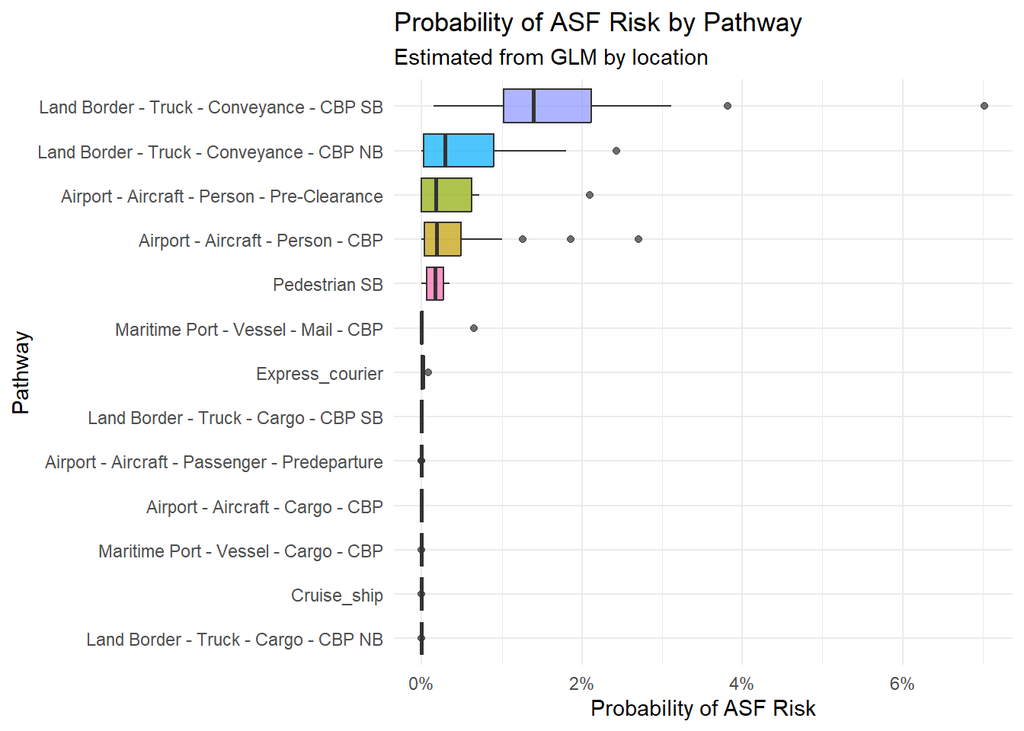

```r
# Create visualization of probabilities by pathway and location
library(ggplot2)
library(dplyr)
library(scales)

# Define output directory first before saving any plots
output_dir <- here::here("output", "aqim pathway approach rates")
if (!dir.exists(output_dir)) {
  dir.create(output_dir, recursive = TRUE)
}

# Plot probabilities by pathway
pathway_boxplot <- ggplot(all_predictions, aes(x = reorder(pathway, probability), y = probability)) +
  geom_boxplot(aes(fill = pathway), alpha = 0.7) +
  coord_flip() +
  scale_y_continuous(labels = percent_format()) +
  labs(
    title = "Probability of ASF Risk by Pathway",
    subtitle = "Estimated from GLM by location",
    x = "Pathway",
    y = "Probability of ASF Risk",
    fill = "Pathway"
  ) +
  theme_minimal() +
  theme(legend.position = "none")

# Display the plot
print(pathway_boxplot)
```

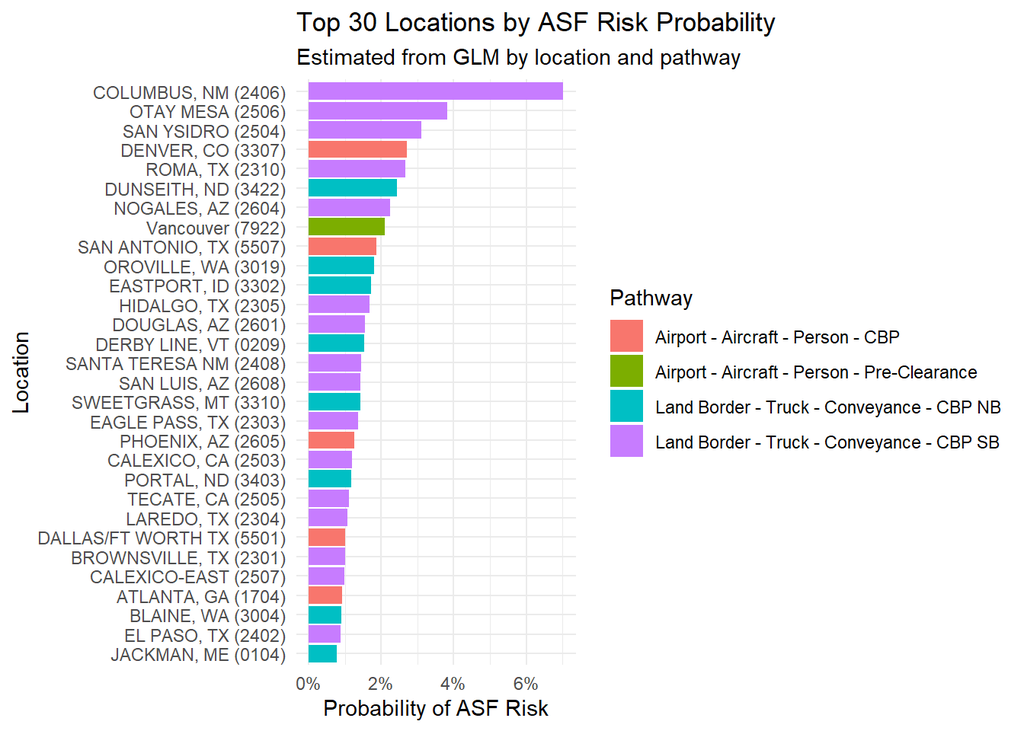

```r
# Save the boxplot to a file
ggsave(
  filename = file.path(output_dir, "pathway_risk_probability_boxplot.png"),
  plot = pathway_boxplot,
  width = 10,
  height = 8,
  dpi = 300
)

# Also save as PDF for higher quality if needed
ggsave(
  filename = file.path(output_dir, "pathway_risk_probability_boxplot.pdf"),
  plot = pathway_boxplot,
  width = 10,
  height = 8
)

# Find the top 30 locations with highest probabilities
top_locations <- all_predictions %>%
  arrange(desc(probability)) %>%
  head(30)

# Plot top 30 locations by probability
top_locations_plot <- ggplot(top_locations, aes(x = reorder(location, probability), y = probability, fill = pathway)) +
  geom_col() +
  coord_flip() +
  scale_y_continuous(labels = percent_format()) +
  labs(
    title = "Top 30 Locations by ASF Risk Probability",
    subtitle = "Estimated from GLM by location and pathway",
    x = "Location",
    y = "Probability of ASF Risk",
    fill = "Pathway"
  ) +
  theme_minimal()

# Display the plot
print(top_locations_plot)
```

```r
# Save the top locations plot to a file
ggsave(
  filename = file.path(output_dir, "top_30_locations_risk_probability.png"),
  plot = top_locations_plot,
  width = 12,
  height = 10,
  dpi = 300
)

# Also save as PDF for higher quality if needed
ggsave(
  filename = file.path(output_dir, "top_30_locations_risk_probability.pdf"),
  plot = top_locations_plot,
  width = 12,
  height = 10
)

# Save the predictions as CSV
write.csv(
  all_predictions,
  file.path(output_dir, "glm_location_predictions.csv"),
  row.names = FALSE
)

# Save as RDS for easier loading in other scripts
saveRDS(
  all_predictions,
  file.path(output_dir, "glm_location_predictions.rds")
)

# Also save the pathway summary
write.csv(
  pathway_summary,
  file.path(output_dir, "glm_pathway_summary.csv"),
  row.names = FALSE
)
```

# Compare predictions with observed data and check model diagnostics

```r
# Create a data frame for model statistics
model_stats <- data.frame(
  pathway = character(),
  AIC = numeric(),
  BIC = numeric(),
  deviance = numeric(),
  df.residual = numeric(),
  stringsAsFactors = FALSE
)

# For each pathway, extract model diagnostics and predictions
for (pathway_name in names(glmm_results)) {
  # Get the model
  model <- glmm_results[[pathway_name]]

  # Extract model statistics
  model_stats <- rbind(
    model_stats,
    data.frame(
      pathway = pathway_name,
      AIC = AIC(model),
      BIC = BIC(model),
      deviance = deviance(model),
      df.residual = df.residual(model),
      stringsAsFactors = FALSE
    )
  )

  # We'll skip plot creation and saving to avoid any issues
  # Just collect the model statistics
}

# Display model statistics
model_stats %>%
  arrange(AIC) %>%
  knitr::kable(caption = "Model fit statistics by pathway", digits = 2)
```

Model fit statistics by pathway

| pathway | AIC | BIC | deviance | df.residual |
| --- | --- | --- | --- | --- |
| Land Border - Truck - Cargo - CBP SB | 4.00 | 1.39 | 0 | 0 |
| Land Border - Truck - Cargo - CBP NB | 12.00 | 10.75 | 0 | 0 |
| Cruise_ship | 16.00 | 16.64 | 0 | 0 |
| Airport - Aircraft - Passenger - Predeparture | 16.00 | 16.64 | 0 | 0 |
| Maritime Port - Vessel - Mail - CBP | 19.67 | 18.42 | 0 | 0 |
| Express_courier | 20.71 | 18.76 | 0 | 0 |
| Airport - Aircraft - Cargo - CBP | 24.00 | 29.82 | 0 | 0 |
| Airport - Aircraft - Person - Pre-Clearance | 30.56 | 29.31 | 0 | 0 |
| Maritime Port - Vessel - Cargo - CBP | 44.00 | 68.00 | 0 | 0 |
| Pedestrian SB | 88.84 | 96.18 | 0 | 0 |
| Land Border - Truck - Conveyance - CBP NB | 146.47 | 176.94 | 0 | 0 |
| Land Border - Truck - Conveyance - CBP SB | 159.80 | 175.83 | 0 | 0 |
| Airport - Aircraft - Person - CBP | 178.72 | 218.37 | 0 | 0 |

```r
# Save model statistics
write.csv(
  model_stats,
  file.path(output_dir, "glm_model_statistics.csv"),
  row.names = FALSE
)
```

# Prepare results for integration with ASF risk framework

```r
# Reshape the predictions to be compatible with the ASF risk framework format
# This creates a format similar to what's expected by other scripts

# Initialize a list to store prediction intervals
prediction_intervals <- list()

# For each pathway, calculate proper prediction intervals using predict.glm
for (pathway_name in names(glmm_results)) {
  # Skip if no model exists for this pathway
  if (is.null(glmm_results[[pathway_name]])) {
    next
  }

  # Get the model and data for this pathway
  model <- glmm_results[[pathway_name]]
  pathway_data <- aqim_dat_list[[pathway_name]]

  # Get pathway predictions
  pathway_predictions <- glmm_predictions[[pathway_name]]

  # Create a data frame for each location with its corresponding location name
  for (i in 1:nrow(pathway_predictions)) {
    location_name <- pathway_predictions$location[i]

    # Create a prediction data frame for this location
    pred_data <- data.frame(INSPECTION_LOCATION_NAME = location_name)

    # Calculate prediction intervals on the link scale (logit)
    tryCatch({
      # Set se.fit=TRUE to get standard errors
      preds <- predict(model, newdata = pred_data,
                      type = "link", se.fit = TRUE)

      # Calculate confidence intervals on the link scale
      link_lower <- preds$fit - 1.96 * preds$se.fit
      link_upper <- preds$fit + 1.96 * preds$se.fit

      # Transform back to probability scale
      prob_fit <- plogis(preds$fit)
      prob_lower <- plogis(link_lower)
      prob_upper <- plogis(link_upper)

      # Store results
      prediction_intervals[[paste(pathway_name, location_name, sep = "_")]] <-
        data.frame(
          pathway = pathway_name,
          location = location_name,
          pred_prob = prob_fit,
          lower_prob = prob_lower,
          upper_prob = prob_upper
        )
    }, error = function(e) {
      # If prediction fails, use the probability directly from pathway_predictions
      prob <- pathway_predictions$probability[i]

      # Fallback to simple approximation for CI calculation
      se <- sqrt(prob * (1 - prob) / 30)  # Assuming at least 30 observations per location

      prediction_intervals[[paste(pathway_name, location_name, sep = "_")]] <-
        data.frame(
          pathway = pathway_name,
          location = location_name,
          pred_prob = prob,
          lower_prob = max(0, prob - 1.96 * se),
          upper_prob = min(1, prob + 1.96 * se)
        )

      cat("Warning: Using fallback CI calculation for", location_name, "in", pathway_name, "\n")
    })
  }
}
# Combine all intervals into one data frame
all_intervals <- do.call(rbind, prediction_intervals)

# Join the intervals with original predictions
integration_data <- all_predictions %>%
  rename(
    INSPECTION_LOCATION_NAME = location,
    pred_prob = probability
  ) %>%
  left_join(
    all_intervals %>%
      rename(INSPECTION_LOCATION_NAME = location) %>%
      dplyr::select(pathway, INSPECTION_LOCATION_NAME, lower_prob, upper_prob),
    by = c("pathway", "INSPECTION_LOCATION_NAME")
  )

# Display the integration-ready format
head(integration_data)
```

```
##                            pathway          INSPECTION_LOCATION_NAME  log_odds
## 1 Airport - Aircraft - Cargo - CBP                ATLANTA, GA (1704) -31.01084
## 2 Airport - Aircraft - Cargo - CBP BOSTON - LOGAN AIRPORT, MA (0417) -30.75761
## 3 Airport - Aircraft - Cargo - CBP                CHICAGO, IL (3901) -31.24892
## 4 Airport - Aircraft - Cargo - CBP         DALLAS/FT WORTH TX (5501) -30.56609
## 5 Airport - Aircraft - Cargo - CBP    DULLES - WASHINGTON, DC (5401) -30.58006
## 6 Airport - Aircraft - Cargo - CBP           HONOLULU AIRPORT (3205) -30.68534
##      pred_prob lower_prob upper_prob
## 1 3.405371e-14          0          1
## 2 4.386719e-14          0          1
## 3 2.683906e-14          0          1
## 4 5.312730e-14          0          1
## 5 5.239002e-14          0          1
## 6 4.715484e-14          0          1
```

```r
# Group the data by PATHWAY, container, product_pathway, and product_subpathway
# to determine the proportion of product types within each pathway
product_proportions <- aqim_dat %>%
  # Select only relevant columns
  dplyr::select(PATHWAY, container, product_pathway, product_subpathway, IS_ASF_RISK) %>%
  # Group by pathway and product attributes
  group_by(PATHWAY, container, product_pathway, product_subpathway) %>%
  # Count observations and at-risk items
  summarize(
    risk_count = sum(IS_ASF_RISK > 0),
    .groups = "drop"
  ) %>%
  # Filter out combinations with no risk
  filter(risk_count > 0) %>%
  # Group by pathway to calculate proportions
  group_by(PATHWAY) %>%
  mutate(
    # Calculate proportion relative to pathway total
    pathway_total = sum(risk_count),
    proportion = risk_count / pathway_total
  ) %>%
  ungroup()

# Display summary of product proportions
product_summary <- product_proportions %>%
  group_by(PATHWAY) %>%
  summarize(
    total_combinations = n(),
    total_risk_count = sum(risk_count),
    max_proportion = max(proportion),
    min_proportion = min(proportion),
    .groups = "drop"
  )

print("Summary of product type proportions by pathway:")
```

```
## [1] "Summary of product type proportions by pathway:"
```

```r
print(product_summary)
```

```
## # A tibble: 7 × 5
##   PATHWAY      total_combinations total_risk_count max_proportion min_proportion
##   <chr>                     <int>            <int>          <dbl>          <dbl>
## 1 Airport - A…                  3             1188          0.949       0.00253
## 2 Airport - A…                  2              317          0.874       0.126
## 3 Express_cou…                  5               23          0.739       0.0435
## 4 Land Border…                  4              906          0.672       0.00773
## 5 Land Border…                  5             4137          0.912       0.000242
## 6 Maritime Po…                  2               20          0.8         0.2
## 7 Pedestrian …                  3              564          0.977       0.00709
```

```r
# Combine the product proportions with the prediction intervals
# For each pathway-location combination in integration_data,
# multiply the probabilities by each product type proportion

# Create a list to store the results
product_risk_by_pathway <- list()

# Process each pathway
for (pathway_name in unique(product_proportions$PATHWAY)) {
  # Get integration data for this pathway
  pathway_data <- integration_data %>%
    filter(pathway == pathway_name)

  # Get product proportions for this pathway
  pathway_props <- product_proportions %>%
    filter(PATHWAY == pathway_name)
    # For each product type in this pathway
  for (i in seq_len(nrow(pathway_props))) {
    product_row <- pathway_props[i, ]
    product_name <- paste(product_row$container, product_row$product_pathway,
                          product_row$product_subpathway, sep=";")

    # Create a data frame for this product type
    product_data <- pathway_data %>%
      mutate(
        container = product_row$container,
        product_pathway = product_row$product_pathway,
        product_subpathway = product_row$product_subpathway,
        product_proportion = product_row$proportion,
        # Multiply probabilities by product proportion
        adjusted_prob = pred_prob * product_row$proportion,
        adjusted_lower = lower_prob * product_row$proportion,
        adjusted_upper = upper_prob * product_row$proportion
      )

    # Add to the list
    product_risk_by_pathway[[paste(pathway_name, product_name, sep=";")]] <- product_data
  }
}

# Combine all the results
combined_product_risk <- bind_rows(product_risk_by_pathway)

# Validate that the sum of products equals the original predictions
validation <- combined_product_risk %>%
  group_by(pathway, INSPECTION_LOCATION_NAME) %>%
  summarize(
    original_prob = first(pred_prob),
    sum_adjusted_prob = sum(adjusted_prob),
    difference = original_prob - sum_adjusted_prob,
    .groups = "drop"
  )

# Check if the differences are negligible (due to floating point)
validation_summary <- validation %>%
  summarize(
    max_diff = max(abs(difference)),
    mean_diff = mean(abs(difference))
  )

print("Validation of probability calculations:")
```

```
## [1] "Validation of probability calculations:"
```

```r
print(validation_summary)
```

```
## # A tibble: 1 × 2
##   max_diff mean_diff
##      <dbl>     <dbl>
## 1 1.73e-18  6.40e-20
```

```r
# Display a sample of the combined results
head(combined_product_risk)
```

```
##                             pathway          INSPECTION_LOCATION_NAME
## 1 Airport - Aircraft - Person - CBP                      Aruba (7424)
## 2 Airport - Aircraft - Person - CBP                ATLANTA, GA (1704)
## 3 Airport - Aircraft - Person - CBP BOSTON - LOGAN AIRPORT, MA (0417)
## 4 Airport - Aircraft - Person - CBP                BWI AIRPORT (1305)
## 5 Airport - Aircraft - Person - CBP              CHARLOTTE, NC (1512)
## 6 Airport - Aircraft - Person - CBP                CHICAGO, IL (3901)
##     log_odds    pred_prob   lower_prob  upper_prob container product_pathway
## 1 -27.825002 8.236739e-13 0.0000000000 1.000000000   baggage  other products
## 2  -4.682014 9.175382e-03 0.0080805014 0.010417057   baggage  other products
## 3  -6.932545 9.745639e-04 0.0005244404 0.001810325   baggage  other products
## 4  -5.059822 6.306661e-03 0.0049392099 0.008049638   baggage  other products
## 5  -6.255990 1.915250e-03 0.0009580815 0.003825014   baggage  other products
## 6  -6.044709 2.364765e-03 0.0015855038 0.003525674   baggage  other products
##   product_subpathway product_proportion adjusted_prob adjusted_lower
## 1  animal-based feed          0.0479798  3.951971e-14   0.000000e+00
## 2  animal-based feed          0.0479798  4.402330e-04   3.877008e-04
## 3  animal-based feed          0.0479798  4.675938e-05   2.516255e-05
## 4  animal-based feed          0.0479798  3.025923e-04   2.369823e-04
## 5  animal-based feed          0.0479798  9.189332e-05   4.596856e-05
## 6  animal-based feed          0.0479798  1.134609e-04   7.607215e-05
##   adjusted_upper
## 1   4.797980e-02
## 2   4.998083e-04
## 3   8.685904e-05
## 4   3.862200e-04
## 5   1.835234e-04
## 6   1.691611e-04
```

```r
# Save the combined product risk data
saveRDS(
  combined_product_risk,
  file.path(output_dir, paste0(params$glm_results_filename, "_by_product_type"))
)

# Create a summary of product risk by pathway
product_risk_summary <- combined_product_risk %>%
  group_by(pathway, container, product_pathway, product_subpathway) %>%
  summarize(
    avg_adjusted_prob = mean(adjusted_prob),
    avg_adjusted_lower = mean(adjusted_lower),
    avg_adjusted_upper = mean(adjusted_upper),
    product_proportion = first(product_proportion),
    n_locations = n(),
    .groups = "drop"
  ) %>%
  arrange(pathway, desc(avg_adjusted_prob))

# Save the product risk summary
write.csv(
  product_risk_summary,
  file.path(output_dir, "summary_of_risk_by_product.csv"),
  row.names = FALSE
)

# Print summary information
cat("\nProduct type analysis complete.\n")
```

```
##
## Product type analysis complete.
```

```r
cat("Number of pathway-product combinations:", nrow(product_risk_summary), "\n")
```

```
## Number of pathway-product combinations: 24
```

```r
cat("Product risk summary saved to:", file.path(output_dir, "summary_of_risk_by_product.csv"), "\n")
```

```
## Product risk summary saved to: C:/Users/Dalon.White/OneDrive - USDA/Desktop/Projects/asf-risk-framework2/asf-risk-framework2/output/aqim pathway approach rates/summary_of_risk_by_product.csv
```

```r
cat("Detailed product risk data saved to:",
    file.path(output_dir, paste0(params$glm_results_filename, "_raw")), "\n")
```

```
## Detailed product risk data saved to: C:/Users/Dalon.White/OneDrive - USDA/Desktop/Projects/asf-risk-framework2/asf-risk-framework2/output/aqim pathway approach rates/glmm_results_aqim fraction at risk by pathway and location_raw
```

### modify the zeroes

```r
# Define the threshold for near-zero values
zero_threshold <- 0.000001

# Create a copy of the combined product risk data to avoid modifying the original
adjusted_product_risk <- combined_product_risk

# Process each unique combination of PATHWAY, container, product_pathway, and product_subpathway
product_combos <- unique(combined_product_risk[, c("pathway", "container", "product_pathway", "product_subpathway")])

# For each combination
for (i in 1:nrow(product_combos)) {
  # Extract current combination
  current_combo <- product_combos[i, ]

  # Filter data for this combination
  combo_data <- adjusted_product_risk %>%
    filter(
      pathway == current_combo$pathway,
      container == current_combo$container,
      product_pathway == current_combo$product_pathway,
      product_subpathway == current_combo$product_subpathway
    )
    # Find rows with near-zero adjusted probabilities
  zero_rows <- which(combo_data$adjusted_prob < zero_threshold)
  # If any near-zero values exist
  if (length(zero_rows) > 0) {
    # Find the 25th percentile of ALL adjusted probabilities for this combination (not just non-zero)
    all_values <- combo_data$adjusted_prob
      # If there are any values
    if (length(all_values) > 0) {
      # Calculate the 25th percentile of all values
      perc_25 <- quantile(all_values, 0.25)
      # Calculate replacement value (half of the 25th percentile)
      replacement_value <- perc_25 / 2

      # Get indices in the full dataset for the near-zero rows in this combination
      full_indices <- which(
        adjusted_product_risk$pathway == current_combo$pathway &
        adjusted_product_risk$container == current_combo$container &
        adjusted_product_risk$product_pathway == current_combo$product_pathway &
        adjusted_product_risk$product_subpathway == current_combo$product_subpathway &
        adjusted_product_risk$adjusted_prob < zero_threshold
      )

      # Replace the near-zero values
      adjusted_product_risk$adjusted_prob[full_indices] <- replacement_value

      # Also adjust the confidence interval bounds
      # For lower bound, use the same value as adjusted_prob
      adjusted_product_risk$adjusted_lower[full_indices] <- replacement_value

      # For upper bound, use twice the replacement value (but not more than the original upper bound)
      adjusted_product_risk$adjusted_upper[full_indices] <- pmin(
        adjusted_product_risk$adjusted_upper[full_indices],
        replacement_value * 2
      )      # Log the replacements
      cat(sprintf(
        "Replaced %d near-zero values for %s/%s/%s/%s with %g (half of 25th percentile %g)\n",
        length(full_indices),
        current_combo$pathway,
        current_combo$container,
        current_combo$product_pathway,
        current_combo$product_subpathway,
        replacement_value,
        perc_25
           ))
    } else {
      # If all values in this combination are below threshold
      cat(sprintf(
        "Warning: All values for %s/%s/%s/%s are below threshold. No replacements made.\n",
        current_combo$pathway,
        current_combo$container,
        current_combo$product_pathway,
        current_combo$product_subpathway
      ))
    }
  }
}
```

```
## Replaced 5 near-zero values for Airport - Aircraft - Person - CBP/baggage/other products/animal-based feed with 8.053e-06 (half of 25th percentile 1.6106e-05)
## Replaced 5 near-zero values for Airport - Aircraft - Person - CBP/baggage/swine products/by-products/personal use or consumption with 0.000159365 (half of 25th percentile 0.000318729)
## Replaced 8 near-zero values for Airport - Aircraft - Person - CBP/baggage/swine products/by-products/smuggled commercial products with 4.23842e-07 (half of 25th percentile 8.47685e-07)
## Replaced 3 near-zero values for Airport - Aircraft - Person - Pre-Clearance/baggage/other products/animal-based feed with 1.1531e-15 (half of 25th percentile 2.30619e-15)
## Replaced 3 near-zero values for Airport - Aircraft - Person - Pre-Clearance/baggage/swine products/by-products/personal use or consumption with 7.9852e-15 (half of 25th percentile 1.59704e-14)
## Replaced 2 near-zero values for Express_courier/package/fomite/personal effects with 6.01246e-15 (half of 25th percentile 1.20249e-14)
## Replaced 2 near-zero values for Express_courier/package/other products/plasma with 1.20249e-14 (half of 25th percentile 2.40498e-14)
## Replaced 2 near-zero values for Express_courier/package/other products/smuggled commercial products with 6.01246e-15 (half of 25th percentile 1.20249e-14)
## Replaced 2 near-zero values for Express_courier/package/other products/unspecified feed with 1.20249e-14 (half of 25th percentile 2.40498e-14)
## Replaced 2 near-zero values for Express_courier/package/swine products/by-products/personal use or consumption with 1.02212e-13 (half of 25th percentile 2.04424e-13)
## Replaced 5 near-zero values for Land Border - Truck - Conveyance - CBP NB/baggage/other products/animal-based feed with 3.20739e-05 (half of 25th percentile 6.41478e-05)
## Replaced 5 near-zero values for Land Border - Truck - Conveyance - CBP NB/baggage/other products/smuggled commercial products with 1.02728e-06 (half of 25th percentile 2.05456e-06)
## Replaced 5 near-zero values for Land Border - Truck - Conveyance - CBP NB/baggage/swine products/by-products/personal use or consumption with 6.95125e-05 (half of 25th percentile 0.000139025)
## Replaced 5 near-zero values for Land Border - Truck - Conveyance - CBP NB/baggage/swine products/by-products/smuggled commercial products with 7.98994e-07 (half of 25th percentile 1.59799e-06)
## Replaced 1 near-zero values for Land Border - Truck - Conveyance - CBP SB/conveyance/fomite/plant based feed with 1.23257e-06 (half of 25th percentile 2.46514e-06)
## Replaced 4 near-zero values for Maritime Port - Vessel - Mail - CBP/package/other products/animal-based feed with 1.063e-15 (half of 25th percentile 2.126e-15)
## Replaced 4 near-zero values for Maritime Port - Vessel - Mail - CBP/package/swine products/by-products/personal use or consumption with 4.25201e-15 (half of 25th percentile 8.50402e-15)
## Replaced 1 near-zero values for Pedestrian SB/baggage/other products/unspecified feed with 4.92818e-06 (half of 25th percentile 9.85636e-06)
## Replaced 1 near-zero values for Pedestrian SB/baggage/swine products/by-products/personal use or consumption with 0.000301714 (half of 25th percentile 0.000603428)
## Replaced 1 near-zero values for Pedestrian SB/baggage/swine products/by-products/smuggled commercial products with 2.1903e-06 (half of 25th percentile 4.3806e-06)
```

```r
# Summarize the changes
before_after_summary <- data.frame(  measure = c("Zero values before", "Zero values after", "Min non-zero before", "Min non-zero after", "25th percentile before", "25th percentile after"),  value = c(
    sum(combined_product_risk$adjusted_prob < zero_threshold),
    sum(adjusted_product_risk$adjusted_prob < zero_threshold),
    min(combined_product_risk$adjusted_prob[combined_product_risk$adjusted_prob >= zero_threshold]),
    min(adjusted_product_risk$adjusted_prob[adjusted_product_risk$adjusted_prob >= zero_threshold]),
    quantile(combined_product_risk$adjusted_prob, 0.25),
    quantile(adjusted_product_risk$adjusted_prob, 0.25)
  )
)

# Display summary of changes
print(before_after_summary)
```

```
##                  measure        value
## 1     Zero values before 6.600000e+01
## 2      Zero values after 3.700000e+01
## 3    Min non-zero before 1.297767e-06
## 4     Min non-zero after 1.027278e-06
## 5 25th percentile before 4.074204e-06
## 6  25th percentile after 8.053004e-06
```

```r
# Save the adjusted data
saveRDS(
  adjusted_product_risk,
  file.path(output_dir, paste0(params$glm_results_filename, "_by_product_type_adjusted"))
)
write.csv(
  adjusted_product_risk,
  file.path(output_dir, paste0(params$glm_results_filename, "_by_product_type_adjusted.csv"))
)

adjusted_product_risk <- adjusted_product_risk |>
rename(location = INSPECTION_LOCATION_NAME) |>
mutate(
    scenario = params$affected_countries,
    date_created = Sys.Date(),
    method = "glm",
    # Add group_id for pipeline integration
    group = paste(pathway, container, product_pathway, product_subpathway, sep = ";")
) |> rename(
  probability = adjusted_prob,
  ci_lower = adjusted_lower,
  ci_upper = adjusted_upper
)

# Create a summary of adjusted product risk by pathway with pipeline-compatible format
adjusted_risk_summary <- adjusted_product_risk %>%
  group_by(group, pathway, container, product_pathway, product_subpathway) %>%
  summarize(
    # Using standard names that match pipeline expectations
    probability = mean(probability),
    ci_lower = mean(ci_lower),
    ci_upper = mean(ci_upper),
    # Keep additional metadata fields
    product_proportion = first(product_proportion),
    n_locations = n(),
    .groups = "drop"
  ) %>%
  # Add additional fields needed by the pipeline
  mutate(
    scenario = params$affected_countries,
    date_created = Sys.Date(),
    method = "glm"
  ) %>%
  arrange(pathway, desc(probability))

# Save the adjusted summary in both CSV and RDS formats for pipeline compatibility
write.csv(
  adjusted_risk_summary,
  file.path(output_dir, "avg_of_adjusted_product_risk_summarized_across_locations.csv"),
  row.names = FALSE
)

# Create a new file with only the essential columns for pipeline compatibility
pipeline_ready_data <- adjusted_product_risk |>
  arrange(pathway, desc(probability)) |>
  dplyr::select(
    location,
    pathway,
    group,
    probability,
    ci_lower,
    ci_upper,
    container,
    product_pathway,
    product_subpathway,
    scenario,
    date_created,
    method
  )

# Save the pipeline-ready data
saveRDS(
  pipeline_ready_data,
  file.path(output_dir, paste0(params$glm_results_filename))
)

cat("\nAdjusted product risk data saved to:",
    file.path(output_dir, paste0(params$glm_results_filename, "_by_product_type_adjusted")), "\n")
```

```
##
## Adjusted product risk data saved to: C:/Users/Dalon.White/OneDrive - USDA/Desktop/Projects/asf-risk-framework2/asf-risk-framework2/output/aqim pathway approach rates/glmm_results_aqim fraction at risk by pathway and location_by_product_type_adjusted
```

```r
cat("\nPipeline-ready data saved to:",
    file.path(output_dir, paste0(params$glm_results_filename)), "\n")
```

```
##
## Pipeline-ready data saved to: C:/Users/Dalon.White/OneDrive - USDA/Desktop/Projects/asf-risk-framework2/asf-risk-framework2/output/aqim pathway approach rates/glmm_results_aqim fraction at risk by pathway and location
```

## save group size summary

```r
setwd(here::here('output','aqim pathway approach rates'))
write.csv(group_size_summary, paste(params$group_size_filename,".csv", sep=""), row.names = FALSE)
saveRDS(group_size_summary, paste(params$group_size_filename,".rds", sep=""))
```

## Create Summary

This is to make sure I remember that not all these pathways have risk, so not all of them will be used in the 01_06 aqim pathway risk_PoE.Rmd script

```r
# Create summary statistics for combinations and risk counts
# Count all combinations by risk status
combinations_summary <- aqim_dat |>
  dplyr::count(PATHWAY, container, product_pathway, product_subpathway, IS_ASF_RISK)

# Get key statistics
pathway_counts <- combinations_summary |> distinct(PATHWAY) |> nrow()
total_combinations <- combinations_summary |> distinct(PATHWAY, container, product_pathway, product_subpathway) |> nrow()
risk_combinations <- combinations_summary |> filter(IS_ASF_RISK > 0) |> distinct(PATHWAY, container, product_pathway, product_subpathway) |> nrow()
no_risk_combinations <- combinations_summary |> filter(IS_ASF_RISK == 0) |> distinct(PATHWAY, container, product_pathway, product_subpathway) |> nrow()

# Count observations
total_risk_count <- combinations_summary |> filter(IS_ASF_RISK > 0) |> summarize(total = sum(n)) |> pull(total)
total_no_risk_count <- combinations_summary |> filter(IS_ASF_RISK == 0) |> summarize(total = sum(n)) |> pull(total)
grand_total_count <- sum(combinations_summary$n)

# Create pathway-level summary
pathway_summary <- combinations_summary |>
  group_by(PATHWAY, IS_ASF_RISK) |>
  summarize(count = sum(n), .groups = "drop") |>
  pivot_wider(names_from = IS_ASF_RISK, values_from = count,
              names_prefix = "risk_", values_fill = 0) |>
  mutate(total = risk_0 + risk_1,
         risk_percent = round(100 * risk_1 / total, 1))

# Print summary information
cat("\n### Summary of AQIM Data Combinations ###\n\n")
```

```
##
## ### Summary of AQIM Data Combinations ###
```

```r
cat(paste("Total unique pathways:", pathway_counts, "\n"))
```

```
## Total unique pathways: 13
```

```r
cat(paste("Total unique PATHWAY-container-product combinations:", total_combinations, "\n"))
```

```
## Total unique PATHWAY-container-product combinations: 44
```

```r
cat(paste("- Combinations with ASF risk:", risk_combinations,
          sprintf("(%.1f%%)", 100 * risk_combinations/total_combinations), "\n"))
```

```
## - Combinations with ASF risk: 24 (54.5%)
```

```r
cat(paste("- Combinations without ASF risk:", no_risk_combinations, "\n\n"))
```

```
## - Combinations without ASF risk: 33
```

```r
cat("### Observation Counts ###\n\n")
```

```
## ### Observation Counts ###
```

```r
cat(paste("Total observations:", format(grand_total_count, big.mark=","), "\n"))
```

```
## Total observations: 1,354,358
```

```r
cat(paste("- Observations with ASF risk:", format(total_risk_count, big.mark=","),
          sprintf("(%.1f%%)", 100 * total_risk_count/grand_total_count), "\n"))
```

```
## - Observations with ASF risk: 7,155 (0.5%)
```

```r
cat(paste("- Observations without ASF risk:", format(total_no_risk_count, big.mark=","), "\n\n"))
```

```
## - Observations without ASF risk: 1,347,203
```

```r
cat("###  Pathways by Risk Percentage ###\n\n")
```

```
## ###  Pathways by Risk Percentage ###
```

```r
top_risk_pathways <- pathway_summary |>
  filter(risk_1 > 0) |>
  arrange(desc(risk_percent))

print(top_risk_pathways |> dplyr::select(PATHWAY, risk_1, total, risk_percent))
```

```
## # A tibble: 7 × 4
##   PATHWAY                                     risk_1  total risk_percent
##   <chr>                                        <int>  <int>        <dbl>
## 1 Land Border - Truck - Conveyance - CBP SB     4137 268834          1.5
## 2 Airport - Aircraft - Person - Pre-Clearance    317  52944          0.6
## 3 Land Border - Truck - Conveyance - CBP NB      906 144837          0.6
## 4 Airport - Aircraft - Person - CBP             1188 320351          0.4
## 5 Pedestrian SB                                  564 294563          0.2
## 6 Express_courier                                 23  67910          0
## 7 Maritime Port - Vessel - Mail - CBP             20  64296          0
```

```r
print("The pathway combinations that exist are in the following table:")
```

```
## [1] "The pathway combinations that exist are in the following table:"
```

```r
View(combinations_summary)
```

```r
setwd(here::here('output','aqim pathway approach rates'))
#save summary tables for validating the data
write.csv(combinations_summary, "aqim pathway by product combination summary of total vs at risk.csv", row.names = FALSE)
write.csv(pathway_summary, "aqim pathway summary of total vs at risk.csv", row.names = FALSE)
```

## Output Files Summary

```
##
## ### Summary of Output Files ###
```

```
## #### Data Files
```

```
## - Pipeline-ready data: C:/Users/Dalon.White/OneDrive - USDA/Desktop/Projects/asf-risk-framework2/asf-risk-framework2/output/aqim pathway approach rates/glmm_results_aqim fraction at risk by pathway and location
```

```
## - Raw product risk data: C:/Users/Dalon.White/OneDrive - USDA/Desktop/Projects/asf-risk-framework2/asf-risk-framework2/output/aqim pathway approach rates/glmm_results_aqim fraction at risk by pathway and location_by_product_type
```

```
## - Adjusted product risk data: C:/Users/Dalon.White/OneDrive - USDA/Desktop/Projects/asf-risk-framework2/asf-risk-framework2/output/aqim pathway approach rates/glmm_results_aqim fraction at risk by pathway and location_by_product_type_adjusted
```

[output not shown]

```
## - GLM location predictions: C:/Users/Dalon.White/OneDrive - USDA/Desktop/Projects/asf-risk-framework2/asf-risk-framework2/output/aqim pathway approach rates/glm_location_predictions.csv
```

```
## - GLM pathway summary: C:/Users/Dalon.White/OneDrive - USDA/Desktop/Projects/asf-risk-framework2/asf-risk-framework2/output/aqim pathway approach rates/glm_pathway_summary.csv
```

```
## - Group size summary: C:/Users/Dalon.White/OneDrive - USDA/Desktop/Projects/asf-risk-framework2/asf-risk-framework2/output/aqim pathway approach rates/aqim_mean_pathway_group_size.csv
```

```
## #### Plot Files
```

```
## - Pathway Risk Probability Boxplot (PNG): C:/Users/Dalon.White/OneDrive - USDA/Desktop/Projects/asf-risk-framework2/asf-risk-framework2/output/aqim pathway approach rates/pathway_risk_probability_boxplot.png
```

```
## - Pathway Risk Probability Boxplot (PDF): C:/Users/Dalon.White/OneDrive - USDA/Desktop/Projects/asf-risk-framework2/asf-risk-framework2/output/aqim pathway approach rates/pathway_risk_probability_boxplot.pdf
```

```
## - Top 30 Locations Risk Plot (PNG): C:/Users/Dalon.White/OneDrive - USDA/Desktop/Projects/asf-risk-framework2/asf-risk-framework2/output/aqim pathway approach rates/top_30_locations_risk_probability.png
```

```
## - Top 30 Locations Risk Plot (PDF): C:/Users/Dalon.White/OneDrive - USDA/Desktop/Projects/asf-risk-framework2/asf-risk-framework2/output/aqim pathway approach rates/top_30_locations_risk_probability.pdf
```

[output not shown]